# 1 Learning Objectives

1. Group temporal data into different categories (days, weeks, months and years)

When working with data is important for data analysts to understand that data aggregation can hide a lot of things.

For example, when you rely on monthly case counts to tell you the entire story about the development of new disease cases, there is a lot granular data you are not taking advantage of.

Disaggregating (separating) monthly data into weekly case counts and even daily counts might reveal more information about the progression of diseases, or trend of sales of a product.

We are going to use the ebola_sierraleone_2014 data set from the `{outbreaks}` package to explore historical Ebola outbreak data and demonstrate this concept.

Run the code chunk below to create an R object called ebola_data. With `head(ebola_data)` function, you can explore the initial rows of the data set.

```r
#Create an R object named ebola_data
ebola_data <- outbreaks::ebola_sierraleone_2014
head(ebola_data) #show the first 6 rows of the ebola_data
```

```
##   id age sex    status date_of_onset date_of_sample district    chiefdom
## 1  1  20   F confirmed    2014-05-18     2014-05-23 Kailahun  Kissi Teng
## 2  2  42   F confirmed    2014-05-20     2014-05-25 Kailahun  Kissi Teng
## 3  3  45   F confirmed    2014-05-20     2014-05-25 Kailahun Kissi Tonge
## 4  4  15   F confirmed    2014-05-21     2014-05-26 Kailahun  Kissi Teng
## 5  5  19   F confirmed    2014-05-21     2014-05-26 Kailahun  Kissi Teng
## 6  6  55   F confirmed    2014-05-21     2014-05-26 Kailahun  Kissi Teng
```

The `names(ebola_data)` function would show the names of the different columns.

```r
names(ebola_data)
```

```
## [1] "id"             "age"            "sex"            "status"
## [5] "date_of_onset"  "date_of_sample" "district"       "chiefdom"
```

It seems intuitive that `ebola_data$date_of_onset` and `ebola_data$date_of_sample` are columns containing date information. Let us confirm that by checking the class of the columns.

```r
class(ebola_data$date_of_onset)
```

```
## [1] "Date"
```

```r
class(ebola_data$date_of_sample)
```

```
## [1] "Date"
```

Here is a monthly breakdown of a past epidemic of Ebola. We see that there is a peak in October-December.

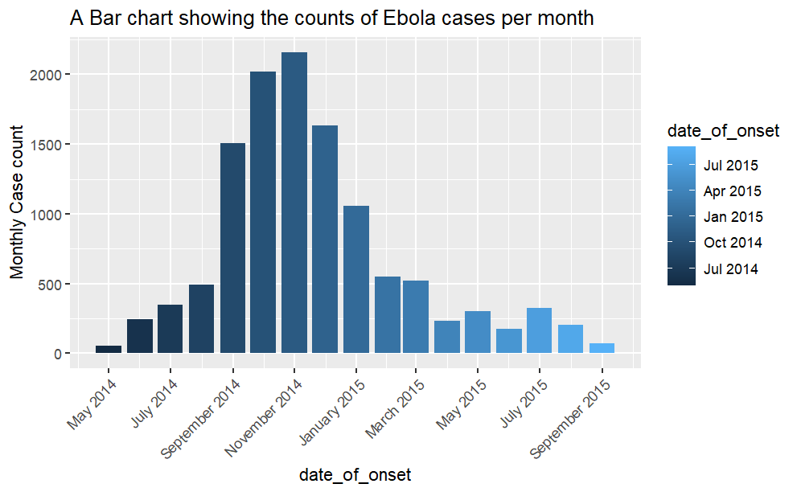

To create the bar chart of monthly totals of new Ebola cases above, we would use the `floor_date()` from the `{lubridate}` package.

`lubridate::(floor_date)` takes a date-time object and rounds it down to the nearest boundary of the specified unit.

The `unit` argument of `lubridate::(floor_date)` can specify either one of the following as character strings. (Second, minute, hour, day, week, month, bimonth, quarter, season, halfyear and year.)

For example, let’s apply `floor_date()` to today’s date. `floor_date()` takes the current date provided by the function `lubridate::today()` and rounds it down to the first day of the particular month as shown below.

```r
lubridate::today() #gives the current date in yyyy-mm-dd format
```

```
## [1] "2022-06-20"
```

```r
lubridate::floor_date(lubridate::today(), unit = "months")
```

```
## [1] "2022-06-01"
```

What would be the result if the function `lubridate::floor_date(x, unit= "months")` is applied to Valentine’s day 2022? In other words, round 2022-02-14 down to the first day of the particular month in the year 2022.

```r
q1 <- "YOUR ANSWER HERE"
.check_q1()
```

```
## You should paste the whole text of only one of the options.
##   1   2
```

```r
.hint_q1()
```

[output not shown]

```
## [1] "2021-02-01"
```

```
## [1] "2022-02-01"
```

```
## [1] "2022-03-01"
```

## 1.1 Monthly cases

Let us get the number of total Ebola cases per month.

**Assumptions**

To answer this question, we assume that each individual `date_of_onset` entry represents a unique case of Ebola.

Thus, to get the total unique cases per month, we would use the `{dplyr}` function `mutate()` and the `lubridate::floor_date()` to modify the `date of onset` column and separate the data by months.

That is what this section of code does.

```r
dplyr::mutate(date_of_onset = lubridate::floor_date(date_of_onset, unit = "months"))
```

Then, the following section of code `count(date_of_onset)` counts the number of unique instances of `date_of_onset` grouped by months.

To ensure that, all possible dates are included in the new column month_onset, use the `complete()` function from the `{tidyr}` package to create a sequence of dates and the argument `fill=list(n=0)`sets to zero (0) any dates that did not have corresponding inputs (cases). Run `?complete` for more details.

Without this step, any graph or table you create may not display time units (that is months) with zero reported cases.

The code below follows the sequence described to get the total monthly cases

```r
total_monthly_cases <- ebola_data%>%
  mutate(month_onset = lubridate::floor_date(date_of_onset, unit = "months"))%>%
  # new column, 1st of month of onset
  count(month_onset) %>% # count cases by month
  tidyr::complete(
    month_onset = seq.Date(
      min(month_onset, na.rm=T),# include all months with no cases reported
      max(month_onset, na.rm=T),
      by="month"),
    fill = list(n = 0))
```

We are using mutate, group_by, count and filter functions from the `{dpylr}` package (part of the tidyverse packages) for data wrangling and the `{ggplot2}` package for plotting graphs.

### 1.1.1 Plotting Monthly case totals

Run the following code to plot the monthly Ebola case totals

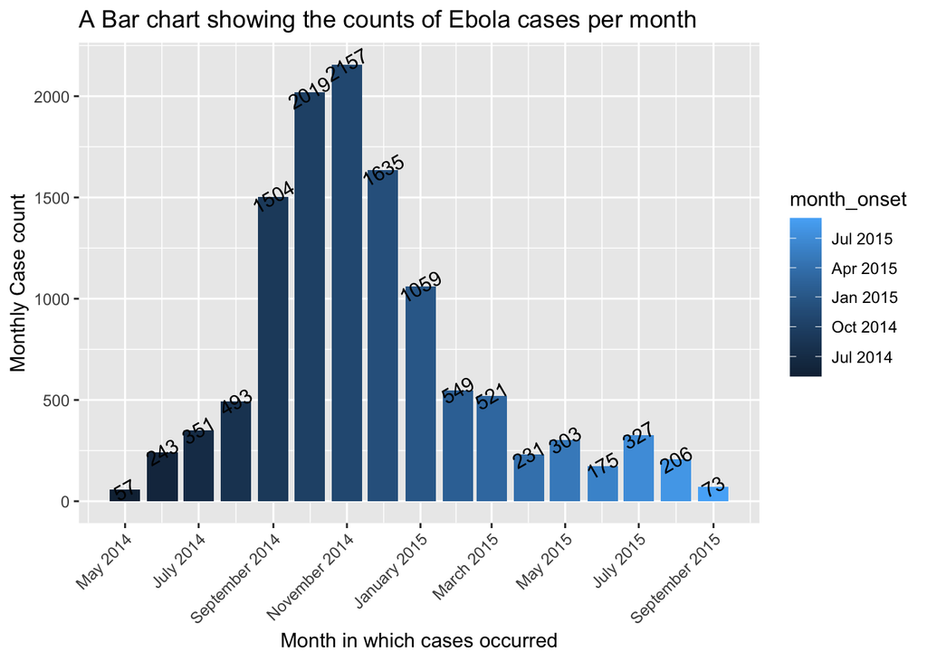

```r
total_monthly_cases%>%
  ggplot(aes(x=month_onset,y=n,fill= month_onset))+geom_col()+
  scale_x_date(date_breaks= "2 month",date_labels = "%B %Y")+
  guides(x = guide_axis(angle = 45))+
  labs(title= "A Bar chart showing the counts of Ebola cases per month")+
  ylab("Monthly Case count")+xlab("Month in which cases occurred")+
  geom_text(aes(label=n),angle=30,check_overlap= T)# to display case counts as labels
```

`guides( x = guide_axis(angle = 45)` is a `{ggplot2}` function that can be used to change the direction of the axis labels on a graph. In the code above we use it to create diagonal axis labels by indicating `angle= 45`.

Refer to the graph above and find the average number of Ebola cases (mean) for the 3 month period from May 2014 to July 2014. Select the correct answer from the options below.

```r
q1 <- "YOUR ANSWER HERE"
.check_q2()
.hint_q2()
```

```
## [1] 217
```

```
## [1] 362.3333
```

```
## [1] 782.6667
```

## 1.2 Daily Cases

Now imagine we were monitoring the cases real-time in 2014 at the very beginning of the epidemic, a case of Ebola has been declared and we need to start looking day by day if we have a growing epidemic on our hands.

Let’s follow the code below to plot the daily case rate over May 2014 to see the progression of the spread of Ebola.

```r
daily_cases <- ebola_data %>%

  count(date_of_onset) %>%      # count number of rows per unique date
  complete(                      # ensure all days appear even if no cases
    date_of_onset = seq.Date(    # re-define date column as daily sequence of dates
      from = min(date_of_onset, na.rm=T),
      to = max(date_of_onset, na.rm=T),
      by = "day"),
    fill = list(n = 0))

daily_cases
```

```
## # A tibble: 483 × 2
##    date_of_onset     n
##    <date>        <int>
##  1 2014-05-18        1
##  2 2014-05-19        0
##  3 2014-05-20        2
##  4 2014-05-21        4
##  5 2014-05-22        6
##  6 2014-05-23        1
##  7 2014-05-24        2
##  8 2014-05-25        0
##  9 2014-05-26       10
## 10 2014-05-27        8
## # … with 473 more rows
```

The table above shows a sequence of dates from May 2014 to September 2015 and their associated record of new cases of Ebola. To plot the trend of cases in the first month of the epidemic, we would have to isolate the cases that occurred in May 2014.

Thus, we would use the `lubridate::month()` function to create a new column containing only the month component of the date_of_onset. Also, the `lubridate::year()` will be used to extract the year column.

### 1.2.1 Plotting daily case totals

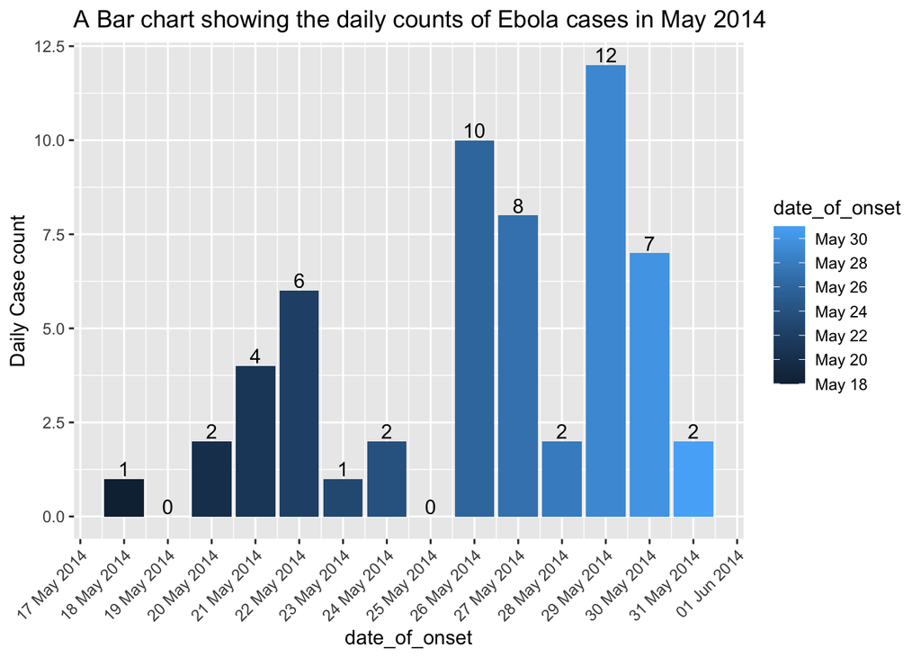

```r
daily_cases%>%
  mutate(month_onset=lubridate::month(date_of_onset, label = TRUE, abbr = FALSE),
         year_onset= lubridate::year(date_of_onset))%>%
  filter(month_onset=="May" & year_onset== 2014)%>%
  ggplot(aes(x=date_of_onset,y=n,fill= date_of_onset))+geom_col()+
  scale_x_date(date_breaks= "1 day",date_labels = "%d %b %Y")+
  guides(x = guide_axis(angle = 45))+
  labs(title= "A Bar chart showing the daily counts of Ebola cases in May 2014")+
  ylab("Daily Case count")+
  geom_text(aes(label=n),check_overlap= T, vjust= -0.2)
```

## 1.3 Weekly Case counts

The plot above shows the trend of the first days of the Ebola outbreak in May 2014.

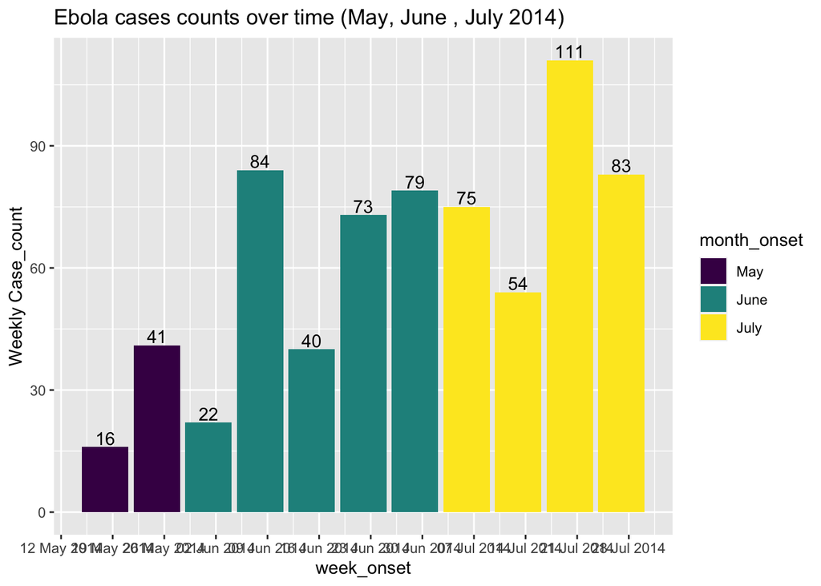

```r
weekly_counts <-
  ebola_data%>%# remove cases missing date_onset
  mutate(week_onset = lubridate::floor_date(date_of_onset, unit = "week")) %>%  # new column of week of onset
  count(week_onset) %>%  # group data by week and count rows per group
  tidyr::complete(    # ensure all days appear even if no cases
    week_onset = seq.Date(# re-define date column as daily sequence of dates
      from = min(week_onset, na.rm=T),
      to = max(week_onset, na.rm=T),
      by = "week"),
    fill = list(n = 0))

weekly_counts%>%
           mutate(year_onset=lubridate::year(week_onset),
                 month_onset=lubridate::month(week_onset, label= TRUE,
                                              abbr= FALSE))%>%
    filter(month_onset %in% c("May","June","July")&
             year_onset==2014)%>%
    ggplot(aes(x=week_onset, y= n, fill= month_onset)) +geom_col()+
  scale_x_date(date_breaks = "1 week", date_labels = "%d %b %Y")+
  labs(title="Ebola cases counts over time (May, June , July 2014)")+
  ylab("Weekly Case_count")+
  geom_text(aes(label=n),check_overlap= T, vjust= -0.2)
```

We can see that generally there is an increase in case counts with a sharp increase in cases in the week of 9th June, 2014.

[output not shown]

# Contributors

The following team members contributed to this lesson:

- [AMA KORANTEMA OWUSU-DARKO](https://thegraphnetwork.training/members/aowusuda/)  
  Data Analyst

  Passionate about equipping health professionals with data analysis skills to promote evidence based research.

# References

Some material in this lesson was adapted from the following sources:

- *Batra, Neale, et al. (2021). The Epidemiologist R Handbook. Chapter 28: GIS Basics*. (2021). Retrieved 01 April 2022, from https://epirhandbook.com/en/gis-basics.html
- *Wickham, Hadley, and Garrett Grolemund.”R For Data Science.”* 16 Dates and times | R for Data Science, 2017. Accessed May 10, 2022 https://r4ds.had.co.nz/dates-and-times.html#time-zones.

This work is licensed under the [Creative Commons Attribution Share Alike](https://creativecommons.org/licenses/by-sa/4.0/) license.